# Обобщенные линейные модели с бинарным откликом

Линейные модели…

Вадим Хайтов, Валентина Домашкина, Анастасия Лянгузова, Наталья Арбузова, Юта Тамберг, Марина Варфоломеева

Кафедра Зоологии беспозвоночных, СПбГУ

# Бинарные переменные вокруг нас

## Числа и События

До сих пор в качестве переменной отклика мы рассматривали числовые данные.

- Содержание сухого вещества в икре
- Вес младенцев
- Объем легких
- Число посещений цветков опылителями.

А как быть, если мы хотим проанализировать связь появления того или иного **события** (произошло или не произошло) с некоторыми предикторами?

## События и предикторы

В зависимости от предикторов события могут происходить чаще или реже — логика, совпадающая с логикой связи количественной переменной отклика с набором предикторов.

Например, по мере роста температуры воздуха летом чаще будут встречаться люди в шортах: событие “встретился человек в шортах” положительно связано с температурой воздуха.

Событие “покупка автомобиля” явно связана с предиктором “количество денег на счете”, однако эта связь может быть совсем непростой.

## Бинарные данные вокруг нас

Бинарные данные — очень распространенный тип зависимых переменных

- Кто-то в результате лечебных процедур выжил или умер
- Обследованное животное заражено паразитами или здорово
- Футбольная команда выиграла или проиграла
- Блюдо вкусное или невкусное

Все эти события могут быть связаны с самыми разными предикторами и эту связь можно описать с помощью регрессионных моделей.

Обобщенные линейные модели позволяют моделировать в том числе и бинарные данные.

# Пример – морские звезды и мидии

## Различают ли морские звезды два вида мидий?

Атлантические мидии (*Mytilus edulis*) коренной для Белого моря вид, но недавно туда вселились мидии другого вида — тихоокеанские мидии (*M. trossulus*).

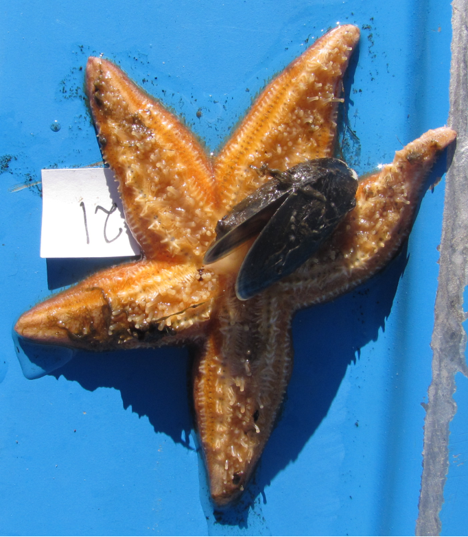

Вселенец имеет меньшую промысловую значимость и потенциально может влиять на структуру экосистемы. Важно понять, что регулирует их численность. Наиболее значимый фактор — это морские звезды, питающиеся мидиями.

- Различают ли морские звезды два вида мидий?
- Различают ли хищники мидий разных размеров?

Данные: Khaitov et al, 2018

## Тонкости дизайна эксперимента

Морских звезд вместе с мидиями двух видов сажали в контейнеры. Через четыре дня совместного существования с хищником регистрировали состояние мидий.

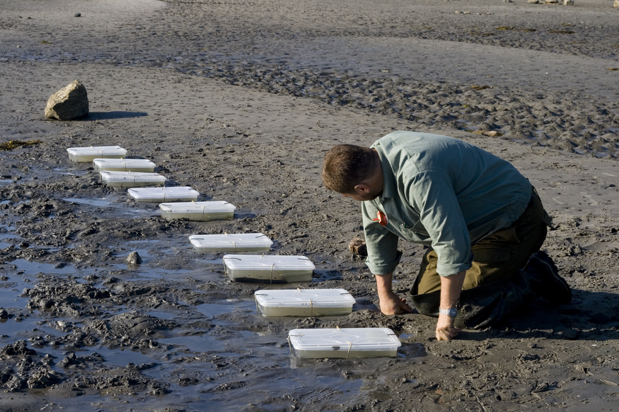

Зависимая переменная: - `Outcome` — состояние мидий (“eaten” — съедена, “not_eaten” — живая)

Предикторы в фокусе исследования: - `Sp` — вид мидий (“Ed” — коренной вид, “Tr” — вселенец), - `L` — размер мидий (мм).

Чего не хватает?

## Как быть с контейнерами?

В этом эксперименте, помимо интересующих нас дискретного фактора `Sp` (вид мидии) и непрерывного предиктора `L` (размер), есть еще один фактор `Box`.

Этот фактор нас не интересует, но его нельзя не учитывать.

Мы должны включить в модель переменную `Box` в качестве дискретного фактора с 4 уровнями.

В лекциях, посвященных **смешанным линейным моделям**, мы научим вас, как включать в модель подобные факторы более правильным способом.

## Читаем данные

```r
astr <- read.csv('data/aster_mussel.csv', header = TRUE)
head(astr)
```

```
  Box    L Sp   Outcome
1   1 33.1 Tr not_eaten
2   1 24.8 Ed not_eaten
3   1 33.0 Ed not_eaten
4   1 18.8 Ed not_eaten
5   1 34.0 Ed not_eaten
6   1 22.6 Ed not_eaten
```

Номер экспериментального контейнера закодирован числами, поэтому превращаем его в фактор.

```r
astr$Box <- factor(astr$Box)
```

## Знакомимся с данными

Нет ли пропущенных значений?

```r
colSums(is.na(astr))
```

```
    Box       L      Sp Outcome
      0       0       0       0
```

Каковы объемы выборок?

```r
table(astr$Box)
```

```
 1  2  3  4
66 68 74 78
```

## Нет ли коллинеарности

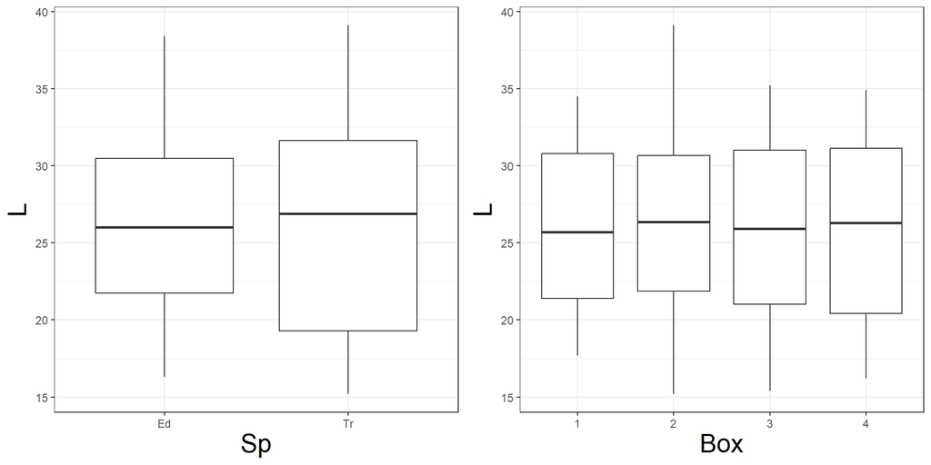

```r
library(ggplot2)
library(cowplot)
theme_set(theme_bw() + theme(axis.title = element_text(size=20)))


Pl_Sp <- ggplot(astr, aes(x = Sp, y = L)) +
  geom_boxplot()
Pl_Box <- ggplot(astr, aes(x = Box, y = L)) +
  geom_boxplot()
plot_grid(Pl_Sp, Pl_Box, ncol = 2)
```

Размер распределен более-менее равномерно. Коллинеарности нет.

## Есть ли выбросы?

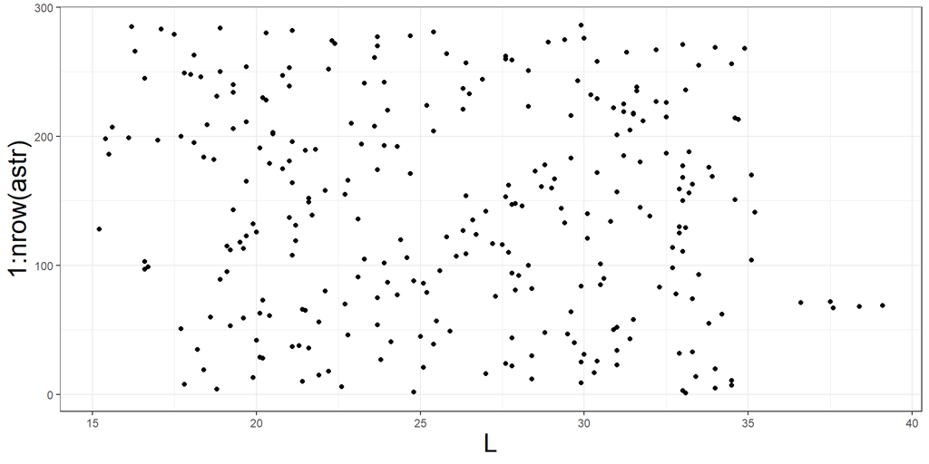

```r
ggplot(astr, aes(y = 1:nrow(astr))) +
  geom_point(aes(x = L))
```

Выбросов нет.

## Кодирование бинарной переменной

До сих пор зависимая переменная была числом, а в данном случае `Outcome` — это текстовая переменная.

Бинарную переменную надо перекодировать в виде нулей и единиц:

- 1 — мидию съели,
- 0 — мидию не съели.

```r
astr$Out <- ifelse(test = astr$Outcome == 'eaten', yes = 1, no = 0)
```

# Простой линейной регрессией не обойтись

## Что мы хотим построить?

Наша задача — построить модель, описывающую связь между переменной-откликом (съедена мидия или нет) и тремя предикторами: `Sp`, `L` и `Box`

Если бы мы строили GLM с нормальным распределением отклика, то она имела бы следующий вид:

$$Out_i \sim N(\mu_i, \sigma)$$

$$E(Out_i) = \mu_i$$

$$\mu_i = \eta_i$$
— функция связи “идентичность”

$$\eta_i = b_0 + b_1Sp_{Tr\,i} + b_2L_i + b_3Box_{2\,i} + b_3Box_{3\,i} + Interactions$$

где $Interactions$ — это все взаимодействия.

## Лобовая атака?

Строим модель по накатанной дороге.

Мы не знаем, взаимодействуют ли дискретные факторы `Box`, `Sp` и непрерывный предиктор `L`.

В полной модели мы должны учесть как влияние самих предикторов, так и влияние их взаимодействия.

```r
mod_norm <- glm(Out ~ Sp * L * Box, data = astr)
```

Все посчиталось…

## Посмотрим что получилось

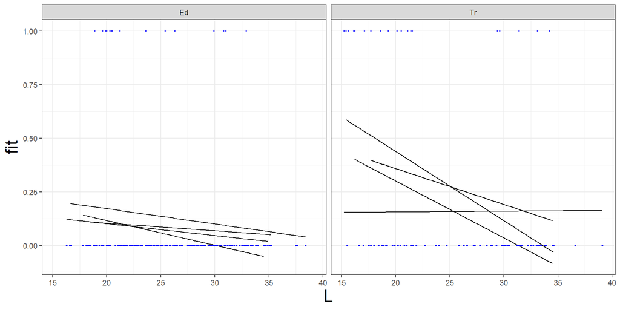

```r
library(dplyr)
new_data <-
  astr %>%
  group_by(Sp, Box) %>%
  do(data.frame(L = seq(min(.$L), max(.$L), length.out = 100)))

new_data$fit <- predict(mod_norm, newdata = new_data) # Предсказанные значения

ggplot(new_data, aes(x = L, y = fit)) +
  geom_line(aes(group = Box)) +
  facet_wrap(~ Sp, ncol = 2) +
  geom_point(data = astr, aes(x = L, y = Out), size = 0.5, color = 'blue')
```

Во-первых, непонятно, что за величина отложена по оси OY.

## Диагностика модели

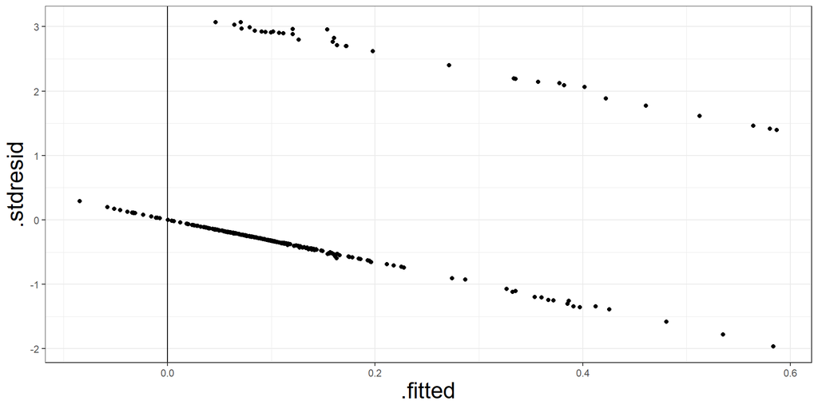

```r
mod_norm_diag <- fortify(mod_norm)
ggplot(mod_norm_diag, aes(x = .fitted, y = .stdresid)) +
  geom_point() + geom_vline(xintercept = 0)
```

Во-вторых, модель предсказывает отрицательные значения.

Простая линейная модель **категорически не годится**!

# Логистическая кривая

## Бинарные данные можно представлять и иначе

Бинарные данные очень неудобны для работы. Вместо того, чтобы моделировать наличие нулей и единиц, мы будем моделировать вероятности получения единиц.

Появляется новое обозначение:

- $\pi_i$ — вероятность события $y_i = 1$ при данных условиях,
- $1 - \pi_i$ — вероятность альтернативного события $y_i = 0$.

$\pi_i$ — непрерывная величина, варьирующая от 0 до 1.

## Симулированный пример: От дискретных значений к оценкам вероятностей

От 1 и 0 (слева) можно перейти к $\pi_i$ — оценкам вероятности положительных исходов (справа).

Мы можем проиллюстрировать этот переход, изобразив доли в общем количестве исходов **при данном значении предиктора** $p_{y = 1 | x_i}$ (красные точки). И $\pi$, и $p_{y = 1 | x_i}$ варьируют от 0 до 1.

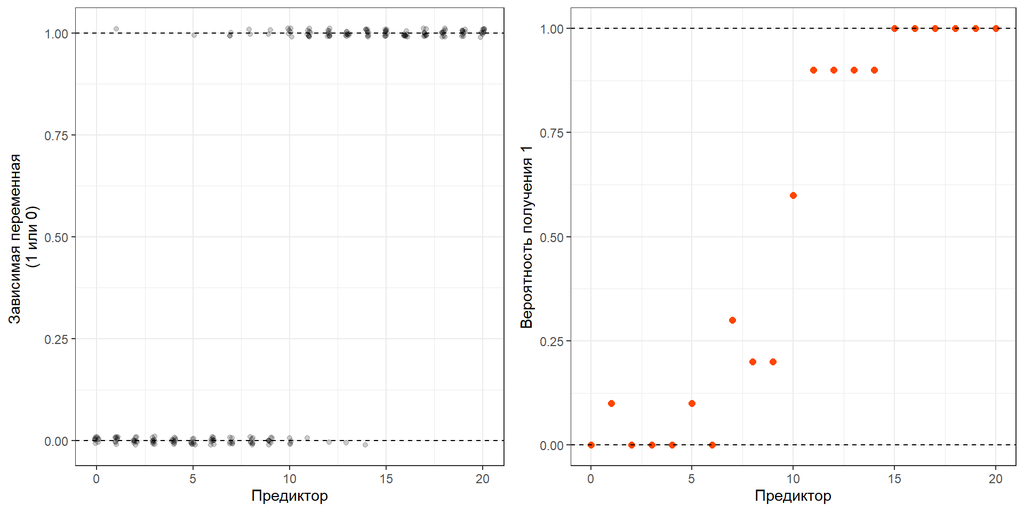

## Симулированный пример: Можно ли подобрать простую линейную регрессию?

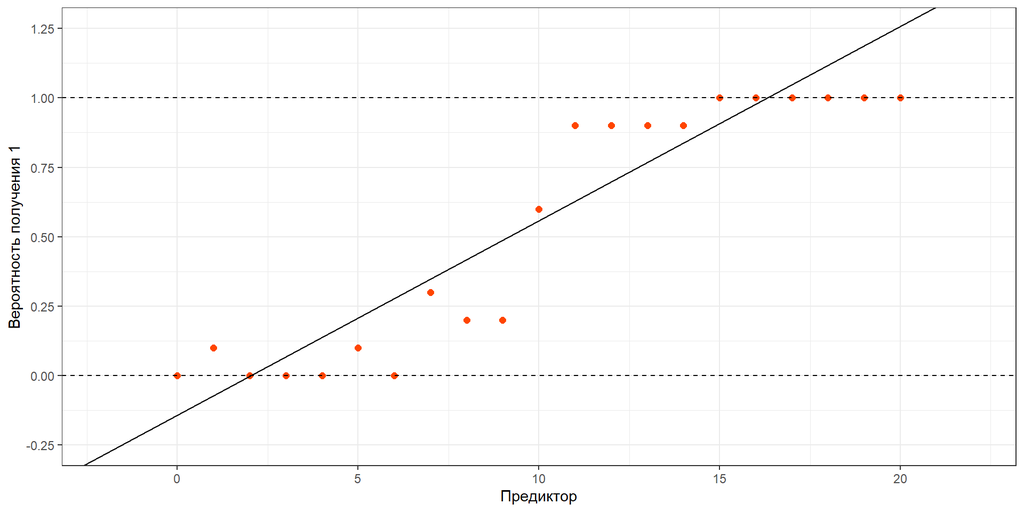

Связь зависимой переменной с предиктором можно было бы описать прямой:

$$\pi_i = \beta_0 + \beta_1x_i$$

Но! Вероятность события может принимать значения только от 0 до 1. А прямая линия ничем не ограничена и может выходить за пределы интервала [0, 1].

## Симулированный пример: Логистическая кривая

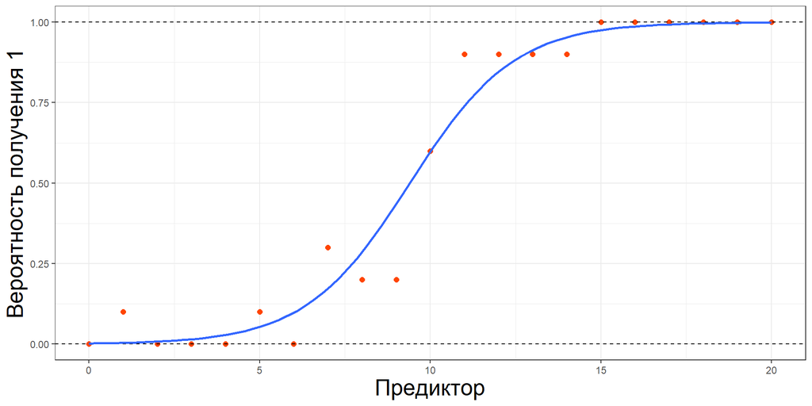

Связь вероятности положительного исхода и значений предиктора можно описать логистической кривой:

$$\pi_i = \frac{e^{\beta_0 + \beta_1x_i}}{1 + e^{\beta_0 + \beta_1x_i}}$$

Логистическая кривая удобна для описания вероятностей, т.к. ее значения лежат в пределах от 0 до 1.

## Симулированный пример: Логистическая кривая

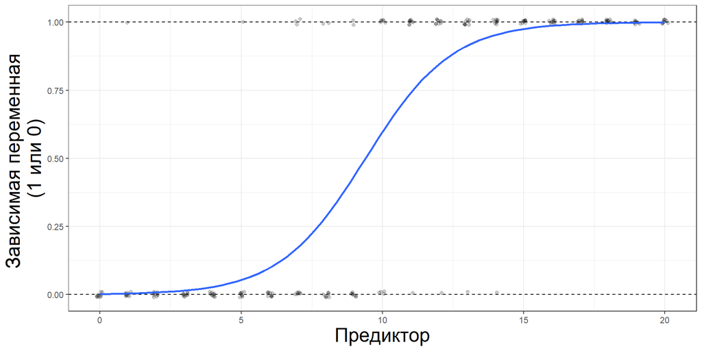

В реальной жизни нам не потребуется даже рассчитывать доли положительных исходов от общего количества.

Благодаря GLM мы сможем оценить вероятности непосредственно по исходным данным.

# Шансы и логиты

## Шансы – еще один способ выразить бинарную переменную отклика

В обыденной речи мы часто используем фразы подобные такой:

“Шансы на победу 1 к 3”: в одном случае выигрыш в трех проигрыш

Шансы — это тоже оценка вероятности события. Шансы показывают сколько в данной системе положительных исходов и сколько отрицательных.

## Отношение шансов

Шансы (odds) часто представляют в виде отношения шансов (odds ratio): $odds = \frac{n_{+}}{n_{-}}$

Если отношение шансов > 1, то вероятность наступления события выше, чем вероятность того, что оно не произойдет. Если отношение шансов < 1, то наоборот.

Если можно оценить вероятность положительного события, то отношение шансов выглядит так: $odds = \frac{\pi}{1-\pi}$

Отношение шансов варьирует от 0 до $+\infty$.

## Отношение шансов

Если отношение шансов = 1, то вероятность того, что событие произойдет равно вероятности того, что событие не произойдет.

Асимметрия: отношение шансов от 1 до $+\infty$ говорит о том, что вероятность того, что событие произойдет, выше, чем вероятность того, что оно не произойдет, но если наоборот, то отношение шансов “зажато” между 0 и 1.

## Логиты

Отношение шансов можно преобразовать в *Логиты* (logit):

$$\ln(odds) = \ln\left(\frac{\pi}{1-\pi}\right)$$

Значения логитов — это трансформированные оценки вероятности события.

Логиты варьируют от $-\infty$ до $+\infty$.

Логиты симметричны относительно 0, т.е. $\ln(1)$.

Для построения моделей в качестве зависимой переменной удобнее брать логиты.

# Немного алгебры: Логиты в качестве зависимой переменной

## Докажем, что логит преобразование линеаризует логистическую кривую

Когда предиктор один, логистическая модель принимает такую форму:

$$\pi = \cfrac{e^{\beta_0 + \beta_1 x}}{1 + e^{\beta_0 + \beta_1 x}}$$

Обозначим для краткости $\beta_0 + \beta_1 x \equiv z$

Давайте докажем, что логит преобразование $logit(\pi) = \ln\left(\cfrac{\pi}{1 - \pi}\right)$ сделает логистическую функцию линейной, т.е. что

$$\ln\left(\cfrac{\pi}{1 - \pi}\right) = z$$

## Подставим выражение для $\pi$ в формулу логита

$$\ln\left(\frac{\pi}{1-\pi}\right) = \ln\left(\frac{\frac{e^z}{1+e^z}}{1-\frac{e^z}{1+e^z}}\right)$$

Логарифм отношения равен разности логарифмов, тогда:

$$\ln\left(\frac{e^z}{1+e^z}\right) - \ln\left(1-\frac{e^z}{1+e^z}\right)$$

Вторую дробь можно упростить:

$$\ln\left(\frac{e^z}{1+e^z}\right) - \ln\left(\frac{1+e^z - e^z}{1+e^z}\right) = \ln\left(\frac{e^z}{1+e^z}\right) - \ln\left(\frac{1}{1+e^z}\right)$$

## Продолжаем преобразования

$$\ln\left(\frac{e^z}{1+e^z}\right) - \ln\left(\frac{1}{1+e^z}\right) = \ln(e^z) - \ln(1+e^z) - (\ln(1) - \ln(1+e^z))$$

$$\ln(e^z) - \ln(1+e^z) - 0 + \ln(1+e^z) = \ln(e^z) = z$$

$$\ln\left(\frac{\pi(x)}{1-\pi(x)}\right) = z = \beta_0 + \beta_1 x$$

Т.е. после логит-преобразования логистическая кривая становится прямой.

## Связывающая функция (link function)

**Мы уже знаем**: Для линеаризации связи между предикторами и зависимой переменной применяется связывающая функция.

Функция логит-преобразования $g(E(y)) = \ln\left(\frac{\pi}{1-\pi}\right)$ это одна из возможных связывающих функций, применяемых для анализа бинарных переменных отклика.

Другие связывающие функции: probit, cloglog.

## Логика математических преобразований

1. От дискретной оценки событий (1 или 0) переходим к оценке вероятностей.
2. Связь вероятностей с предиктором описывается логистической кривой.
3. Если при помощи функции связи перейти от вероятностей к логитам, то связь с предиктором будет описываться прямой линией.
4. Параметры линейной модели для такой прямой можно оценить при помощи линейной модели.

Теперь мы готовы сформулировать модель в математическом виде.

## GLM с биномиальным распределением отклика

$$y_i \sim Binomial(n = 1, \pi_i)$$

$$E(y_i) = \pi_i = \cfrac{e^{\beta_0 + \beta_1 x_{1} + ... + \beta_{p-1}~x_{p-1}}}{1 + e^{\beta_0 + \beta_1 x_{1} + ... + \beta_{p-1}~x_{p-1}}}$$

$$\ln\left(\cfrac{\pi_i}{1 - \pi_i}\right) = \eta_i$$
— функция связи логит, переводит вероятности в логиты.

$$\eta_i = \beta_0 + \beta_1 x_{1\,i} + ... + \beta_{p-1\,i}~x_{p-1\,i}$$

Чтобы перейти обратно от логитов к вероятностям, применяется логистическое преобразование (это функция, обратная функции связи):

$$\pi_i = \cfrac{e^{\eta_i}}{1 + e^{\eta_i}}$$

# Вернемся к морским звездам и мидиям

## GLM с биномиальным распределением отклика

$$Out_i \sim Binomial(n = 1, \pi_i)$$

$$E(Out_i) = \pi_i$$

$$\ln\left(\frac{\pi_i}{1 - \pi_i}\right) = \eta_i$$

$$\pmb{\eta} = \mathbf{X}\pmb{\beta}$$

Полная модель в изучаемой системе включает много членов:

- Главные предикторы: $Sp$, $L$, $Box$
- Взаимодействия первого порядка: $Sp$:$L$, $Sp$:$Box$, $L$:$Box$
- Взаимодействия второго порядка: $Sp$:$L$:$Box$

```r
mod <- glm(Out ~ Sp*L*Box, family = binomial(link = 'logit'), data = astr)
```

## Анализ девиансы для полной модели

```r
library(car)
Anova(mod)
```

```
Analysis of Deviance Table (Type II tests)

Response: Out
         LR Chisq Df Pr(>Chisq)
Sp           7.28  1    0.00696 **
L           12.35  1    0.00044 ***
Box          1.06  3    0.78597
Sp:L         0.05  1    0.82686
Sp:Box       2.57  3    0.46335
L:Box        2.06  3    0.56055
Sp:L:Box     4.86  3    0.18203
---
Signif. codes:  0 '***' 0.001 '**' 0.01 '*' 0.05 '.' 0.1 ' ' 1
```

Эту модель можно упростить!

## Упрощение модели: Шаг 1

```r
drop1(mod, test = 'Chi')
```

```
Single term deletions

Model:
Out ~ Sp * L * Box
         Df Deviance AIC  LRT Pr(>Chi)
<none>           180 212
Sp:L:Box  3      185 211 4.86     0.18
```

```r
mod2 <- update(mod, . ~ . - Sp:L:Box)
```

## Упрощение модели: Шаг 2

```r
drop1(mod2, test = 'Chi')
```

```
Single term deletions

Model:
Out ~ Sp + L + Box + Sp:L + Sp:Box + L:Box
       Df Deviance AIC   LRT Pr(>Chi)
<none>         185 211
Sp:L    1      185 209 0.048     0.83
Sp:Box  3      187 207 2.567     0.46
L:Box   3      187 207 2.058     0.56
```

```r
mod3 <- update(mod2, . ~ . - Sp:L)
```

## Упрощение модели: Шаг 3

```r
drop1(mod3, test = 'Chi')
```

```
Single term deletions

Model:
Out ~ Sp + L + Box + Sp:Box + L:Box
       Df Deviance AIC  LRT Pr(>Chi)
<none>         185 209
Sp:Box  3      188 206 2.65     0.45
L:Box   3      187 205 2.27     0.52
```

```r
mod4 <- update(mod3, . ~ . - L:Box)
```

## Упрощение модели: Шаг 4

```r
drop1(mod4, test = 'Chi')
```

```
Single term deletions

Model:
Out ~ Sp + L + Box + Sp:Box
       Df Deviance AIC   LRT Pr(>Chi)
<none>         187 205
L       1      200 216 12.35  0.00044 ***
Sp:Box  3      190 202  3.01  0.39031
---
Signif. codes:  0 '***' 0.001 '**' 0.01 '*' 0.05 '.' 0.1 ' ' 1
```

```r
mod5 <- update(mod4, . ~ . - Sp:Box)
```

## Упрощение модели: Шаг 5

```r
drop1(mod5, test = 'Chi')
```

```
Single term deletions

Model:
Out ~ Sp + L + Box
       Df Deviance AIC   LRT Pr(>Chi)
<none>         190 202
Sp      1      198 208  7.48  0.00625 **
L       1      202 212 11.81  0.00059 ***
Box     3      191 197  1.12  0.77165
---
Signif. codes:  0 '***' 0.001 '**' 0.01 '*' 0.05 '.' 0.1 ' ' 1
```

```r
mod6 <- update(mod5, . ~ . - Box)
```

## Упрощение модели: Шаг 6

```r
drop1(mod6, test = 'Chi')
```

```
Single term deletions

Model:
Out ~ Sp + L
       Df Deviance AIC   LRT Pr(>Chi)
<none>         191 197
Sp      1      199 203  7.89  0.00496 **
L       1      203 207 11.75  0.00061 ***
---
Signif. codes:  0 '***' 0.001 '**' 0.01 '*' 0.05 '.' 0.1 ' ' 1
```

Больше никаких предикторов исключать нельзя: `mod6` — финальная модель.

## AIC для финальной модели

```r
AIC(mod, mod2, mod3, mod4, mod5, mod6)
```

```
     df AIC
mod  16 212
mod2 13 211
mod3 12 209
mod4  9 205
mod5  6 202
mod6  3 197
```

Информационный критерий Акайке показывает, что по мере удаления предикторов модель становится лучше.

Финальная модель (`mod6`) лучше, чем полная модель, с которой мы начинали.

# Смысл коэффициентов в моделях с бинарной переменной отклика

## Что за модель мы построили?

```r
summary(mod6)
```

```
Call:
glm(formula = Out ~ Sp + L, family = binomial(link = "logit"),
    data = astr)

Coefficients:
            Estimate Std. Error z value Pr(>|z|)
(Intercept)    0.399      0.875    0.46   0.6483
SpTr           1.070      0.379    2.82   0.0047 **
L             -0.113      0.035   -3.24   0.0012 **
---
Signif. codes:  0 '***' 0.001 '**' 0.01 '*' 0.05 '.' 0.1 ' ' 1

(Dispersion parameter for binomial family taken to be 1)

    Null deviance: 212.58  on 285  degrees of freedom
Residual deviance: 191.24  on 283  degrees of freedom
AIC: 197.2

Number of Fisher Scoring iterations: 5
```

$$Out_i \sim Binomial(n = 1, \pi)$$

$$E(Out_i) = \pi_i$$

$$\ln\left(\frac{\pi_i}{1 - \pi_i}\right) = \eta_i$$

$$\eta_i = 0.399 + 1.07 Sp_{\,Tr\,i} - 0.113 L_i$$

## Что означают коэффициенты модели?

$$Out_i \sim Binomial(n = 1, \pi)$$

$$E(Out_i) = \pi_i$$

$$\ln\left(\frac{\pi_i}{1 - \pi_i}\right) = \eta_i$$

$$\eta_i = 0.399 + 1.07 Sp_{\,Tr\,i} - 0.113 L_i$$

- $b_0$ — интерсепт, логарифм отношения шансов для базового уровня дискретного фактора.
- $b_1$ — **на сколько единиц изменяется логарифм отношения шансов** (logit) для данного уровня (`Tr`) дискретного фактора `Sp` по сравнению с базовым уровнем (`Ed`).
- $b_2$ — **на сколько единиц изменяется логарифм отношения шансов** (logit), если значение предиктора (`L`) изменяется на единицу.

## Немного алгебры для понимания сути коэффициентов

Предположим, что у нас в модели есть только один непрерывный предиктор $x$.

Посмотрим, как изменится предсказанные моделью значения, если значение непрерывного предиктора изменится на 1.

Мы знаем, что в терминах логитов модель выглядит вот так:

$$\eta = \ln\left(\frac{\pi}{1 - \pi}\right) = \ln(odds)$$

Тогда разница между значениями $\eta$ для $x+1$ и $x$ — это логарифм соотношения шансов при этих значениях предиктора:

$$\eta_{x+1} - \eta_{x} = \ln(odds_{x+1}) - \ln(odds_x) = \ln\left(\frac{odds_{x+1}}{odds_x}\right)$$

## Продолжим преобразования

$$\ln\left(\frac{odds_{x+1}}{odds_x}\right) = b_0 + b_1(x+1) - b_0 - b_1x = b_1$$

$$\ln\left(\frac{odds_{x+1}}{odds_x}\right) = b_1$$

$$\frac{odds_{x+1}}{odds_x} = e^{b_1}$$

Полученная величина $e^{b_1}$ показывает, **во сколько раз изменится отношение шансов** при увеличении предиктора на единицу.

Для дискретных факторов $e^{b_1}$ покажет, во сколько раз различается отношение шансов для данного уровня по сравнению с базовым.

## Геометрическая интерпретация коэффициентов

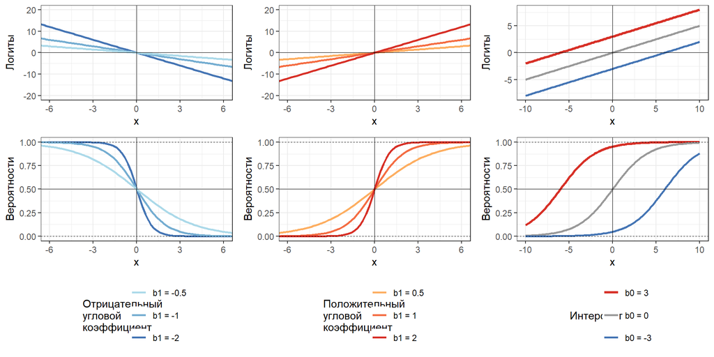

## Смысл интерсепта $b_0$

Величина $e^{b_0}$ показывает отношение шансов для события, когда все предикторы равны нулю.

Когда предикторы физически не могут принимать нулевые значения, у этой величины нет смысла.

Но если произведена стандартизация предикторов, то смысл появится. У стандартизованных величин среднее значение равно нулю. Поэтому $e^{b_0}$ покажет соотношение шансов для события при средних значениях предикторов.

## Трактуем коэффициенты модели

$$\eta_i = 0.399 + 1.07I_{Tr,i} - 0.113L_i$$

- При увеличении длины тела мидии на 1 мм отношения шансов быть съеденной увеличатся в $e^{-0.113}$ = 0.893 раза. То есть мидия, имеющая больший размер, имеет меньше шансов быть съеденной (больше шансов на выживание)
- Отношение шансов быть съеденной у мидии, относящиеся к группе `Tr` дискретного фактора `Sp`, в $e^{1.07}$ = 2.915 раза выше, чем у мидии относящейся к базовому уровню (`Ed`). То есть вероятность выжить у мидии из группы `Tr` меньше, чем у мидии из группы `Ed`.

# Диагностика модели с бинарным откликом

## Условия применимости GLM с бинарной переменной-откликом

- Случайность и независимость наблюдений.
- Линейность связи переменной отклика с предиктором (с учетом связывающей функции).
- Отсутствие сверхдисперсии (форма связи среднего с дисперсией должна быть как у величины с биномиальным распределением).
- Отсутствие коллинеарности предикторов.

## Линейность связи

Мы должны выяснить, нет ли криволинейного паттерна в остатках. Самый простой способ — это построить график остатков от предсказанных значений и наложить на него сглаживающую функцию, подобранную методом loess.

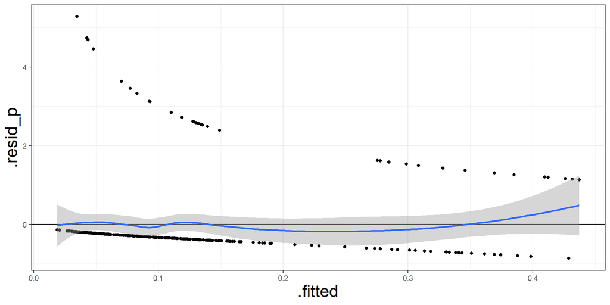

```r
mod6_diag <- data.frame(
  .fitted = predict(mod6, type = 'response'),
  .resid_p = resid(mod6, type = 'pearson')
)
ggplot(mod6_diag, aes(y = .resid_p, x = .fitted)) +
  geom_point() +
  geom_hline(yintercept = 0) +
  geom_smooth(method = 'loess')
```

Явного криволинейного паттерна нет.

## Проверка на сверхдисперсию

Важное свойство биномиального распределения — это зависимость между матожиданием и дисперсией.

Мат. ожидание — $E(y_i) = \pi_i$  
Дисперсия — $var(y_i) = \pi_i (1-\pi_i)$

То есть в распределении остатков не должно наблюдаться сверхдисперсии (overdispersion).

## Еще раз смотрим на результаты

```r
summary(mod6)
```

```
Coefficients:
            Estimate Std. Error z value Pr(>|z|)
(Intercept)    0.399      0.875    0.46   0.6483
SpTr           1.070      0.379    2.82   0.0047 **
L             -0.113      0.035   -3.24   0.0012 **
--
Signif. codes:  0 ‘***’ 0.001 ‘**’ 0.01 ‘*’ 0.05 ‘.’ 0.1 ‘ ’ 1

(Dispersion parameter for binomial family taken to be 1)

    Null deviance: 212.58  on 285  degrees of freedom
Residual deviance: 191.24  on 283  degrees of freedom
AIC: 197.2

Number of Fisher Scoring iterations: 5
```

Важная строчка

```
(Dispersion parameter for binomial family taken to be 1)
```

## Проверка на сверхдисперсию

Используем предложенную Беном Болкером функцию проверки на сверхдисперсию,

```r
# Функция для проверки наличия сверхдисперсии в модели (автор Ben Bolker)
# http://bbolker.github.io/mixedmodels-misc/glmmFAQ.html
# Код модифицирован, чтобы учесть дополнительный параметр в NegBin GLMM,
# подобранных MASS::glm.nb()
overdisp_fun <- function(model) {
  rdf <- df.residual(model)  # Число степеней свободы N - p
  if (any(class(model) == 'negbin')) rdf <- rdf - 1  # учитываем k в NegBin GLMM
  rp <- residuals(model, type = 'pearson')  # Пирсоновские остатки
  Pearson.chisq <- sum(rp^2)  # Сумма квадратов остатков, подчиняется Хи-квадрат распределению
  prat <- Pearson.chisq / rdf  # Отношение суммы квадратов остатков к числу степеней свободы
  pval <- pchisq(Pearson.chisq, df = rdf, lower.tail = FALSE)  # Уровень значимости
  c(chisq = Pearson.chisq, ratio = prat, rdf = rdf, p = pval)  # Вывод результатов
}

overdisp_fun(mod6)
```

```
 chisq  ratio    rdf      p
294.25   1.04 283.00   0.31
```

Избыточной дисперсии не выявлено.

Ben Bolker’s glmmFAQ  
http://bbolker.github.io/mixedmodels-misc/glmmFAQ.html

# Визуализация модели

## Данные для предсказаний

```r
library(dplyr)
new_data <- astr %>% group_by(Sp) %>%
  do(data.frame(L = seq(min(.$L), max(.$L), length.out = 100)))
```

Давайте получим предсказания при помощи операций с матрицами, чтобы своими глазами увидеть работу функции связи.

## Предсказания модели при помощи операций с матрицами

```r
# Модельная матрица и коэффициенты
X <- model.matrix(~ Sp + L, data = new_data)
b <- coef(mod6)

# Предсказанные значения и стандартные ошибки...
# ...в масштабе функции связи (логит)
new_data$fit_eta <- X %*% b
new_data$se_eta <- sqrt(diag(X %*% vcov(mod6) %*% t(X)))

# ...в масштабе отклика (применяем функцию, обратную функции связи)
logit_back <- function(x) exp(x) / (1 + exp(x))  # обратная логит-трансформация

new_data$fit_pi <- logit_back(new_data$fit_eta)
new_data$lwr_pi <- logit_back(new_data$fit_eta - 2 * new_data$se_eta)
new_data$upr_pi <- logit_back(new_data$fit_eta + 2 * new_data$se_eta)

head(new_data, 2)
```

```
# A tibble: 2 × 7
# Groups:   Sp [1]
  Sp        L fit_eta[,1] se_eta fit_pi[,1] lwr_pi[,1] upr_pi[,1]
  <chr> <dbl>       <dbl>  <dbl>      <dbl>      <dbl>      <dbl>
1 Ed     16.3       -1.45  0.374      0.190     0.100       0.332
2 Ed     16.5       -1.47  0.368      0.187     0.0990      0.324
```

## Визуализация в шкале логитов

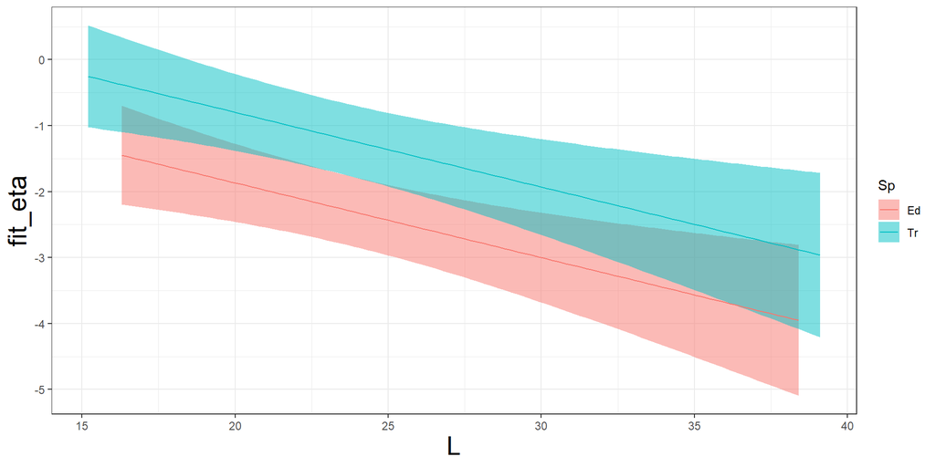

```r
ggplot(new_data, aes(x = L, y = fit_eta, fill = Sp)) +
  geom_ribbon(aes(ymin = fit_eta - 2 * se_eta, ymax = fit_eta + 2 * se_eta), alpha = 0.5) +
  geom_line(aes(color = Sp))
```

Визуализация проведена для логитов, поэтому зависимость линейная, но по оси `OY` отложены значения от $-\infty$ до $+\infty$.

## Визуализация в шкале вероятностей интуитивно понятнее

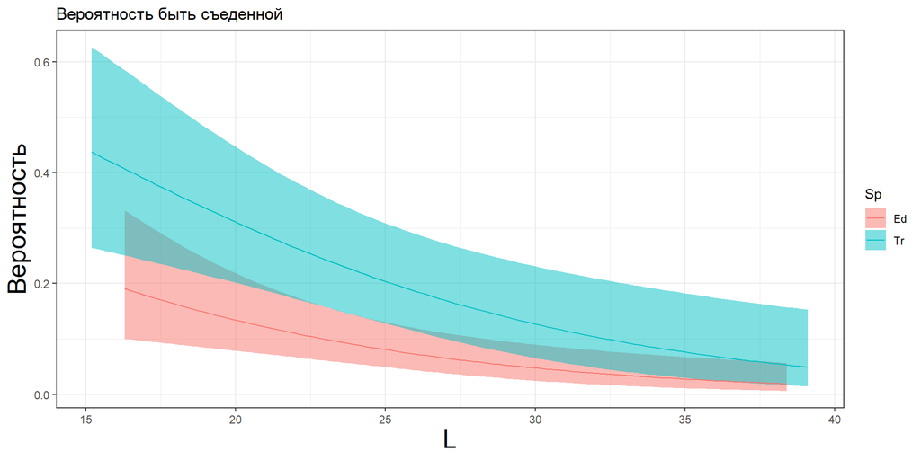

```r
ggplot(new_data, aes(x = L, y = fit_pi, fill = Sp)) +
  geom_ribbon(aes(ymin = lwr_pi, ymax = upr_pi), alpha = 0.5) +
  geom_line(aes(color = Sp)) +
  labs(y = 'Вероятность', title = 'Вероятность быть съеденной')
```

## О чем говорит модель

Чем больше размер мидии, тем меньше вероятность быть съеденной.

Линия, соответствующая `Tr`, лежит выше линии `Ed`. Вероятность быть атакованной у `Tr` выше.

Значит звезды различают два вида мидий и размер жертвы для них имеет значение.

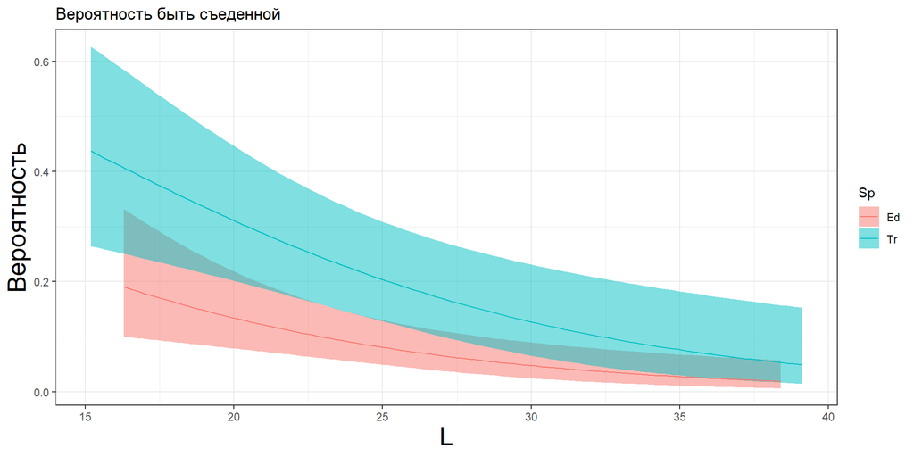

## Take-home messages

### Что мы знаем о бинарных переменных

- Бинарные переменные-отклики могут обозначаться как угодно (+ или -; Да или Нет).
- Удобно кодировать бинарные переменные числами: 1 (событие произошло) или 0 (событие не произошло).
- Вместо бинарных обозначений в анализе используются непрерывные оценки вероятности.
- Вероятности можно перевести в отношения шансов.
- Отношения шансов заменяются логитами.

## Take-home messages

### Что мы знаем о GLM с бинарной переменной-откликом

- GLM с бинарной переменной-откликом называют логистической регрессией.
- Параметры логистической регрессии подбираются методом максимального правдоподобия.
- Угловые коэффициенты логистической регрессии говорят о том, во сколько раз изменяется соотношение шансов для события при увеличении предиктора на единицу (или при переходе от базового уровня фактора к данному уровню).
- Оценить статистическую значимость модели можно с помощью анализа девиансы.
- Для визуализации результатов лучше проводить обратное логит-преобразование и изображать логистические кривые.

## Что почитать

- Кабаков Р.И. R в действии. Анализ и визуализация данных на языке R. М.: ДМК Пресс, 2014.
- Quinn G.P., Keough M.J. (2002) Experimental design and data analysis for biologists, pp. 92-98, 111-130
- Zuur, A.F. et al. 2009. Mixed effects models and extensions in ecology with R. — Statistics for biology and health. Springer, New York, NY.